# Hayman Fire Recovery

Austin Hopkins

07 February, 2022

```r
library(tidyverse)
library(tidyr)
library(ggthemes)
library(lubridate)

# Now that we have learned how to munge (manipulate) data
# and plot it, we will work on using these skills in new ways

knitr::opts_knit$set(root.dir='..')
```

```r
####-----Reading in Data and Stacking it ----- ####
#Reading in files
files <- list.files('data',full.names=T)


#Read in individual data files
files
```

```
## [1] "data/hayman_ndmi.csv" "data/hayman_ndsi.csv" "data/hayman_ndvi.csv"
```

```r
ndmi <- read_csv(files[1]) %>%
  rename(burned=2,unburned=3) %>%
  mutate(data='ndmi')


ndsi <- read_csv(files[2]) %>%
  rename(burned=2,unburned=3) %>%
  mutate(data='ndsi')

ndvi <- read_csv(files[3])%>%
  rename(burned=2,unburned=3) %>%
  mutate(data='ndvi')

# Stack as a tidy dataset
full_long <- rbind(ndvi,ndmi,ndsi) %>%
  gather(key='site',value='value',-DateTime,-data) %>%
  filter(!is.na(value))

view(full_long)
```

## Question 1)

What is the correlation between NDVI and NDMI? - here I want you to convert the full_long dataset in to a wide dataset using the function “spread” and then make a plot that shows the correlation s a function of if the site was burned or not (x axis should be ndmi) You should exclude winter months and focus on summer months

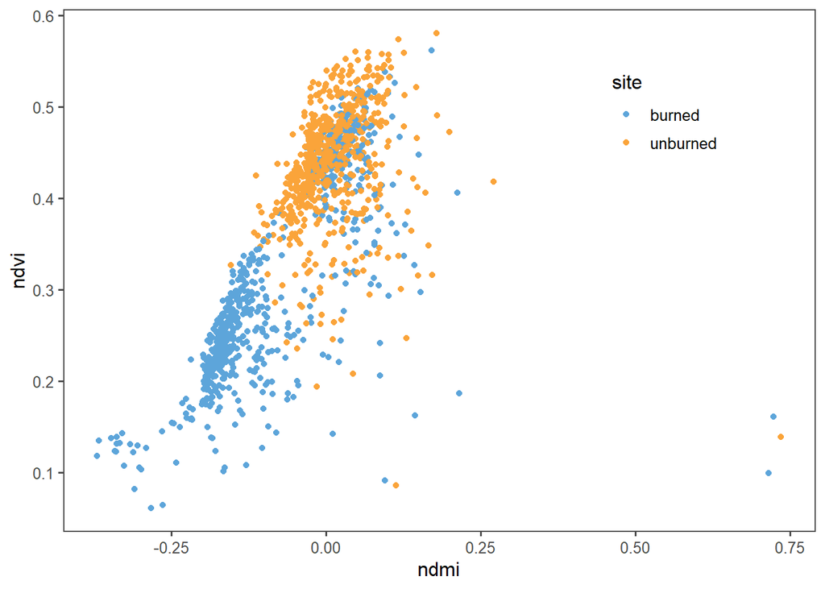

```r
full_wide <- spread(data=full_long,key='data',value='value') %>%
  filter_if(is.numeric,all_vars(!is.na(.))) %>%
  mutate(month = month(DateTime),
         year = year(DateTime))

summer_only <- filter(full_wide,month %in% c(6,7,8,9))

#Figure 1
ggplot(summer_only,aes(x=ndmi,y=ndvi,color=site)) +
  geom_point() +
  theme_few() +
  scale_color_few() +
  theme(legend.position=c(0.8,0.8))
```

Figure 1.

There is a *powerful* positive correlation between the two indices NDMI (I always call it NDWI but to each his own) and NDVI. This makes simple logical sense. During temporal periods that we have more moisture, we are likely to have more vegetation thus more green showing up in the visible bands. We can also see that NDVI is typically higher for the unburned regions than the burned regions. The NDMI is higher in unburned areas which shows a greater potential for moisture/

## Question 2

2. What is the correlation between average NDSI (normalized snow index) for January - April and average NDVI for June-August? In other words, does the previous year’s snow cover influence vegetation growth for the following summer?

```r
jan_april <- filter(full_wide, month %in% c(1,2,3,4))

sum_jan <- jan_april %>%
  group_by(year,site) %>%
  summarise(mean_ndsi=mean(ndsi)) %>%
  mutate("year-site" = paste(year,site,sep=""))
sum_aug <- summer_only %>%
  group_by(year,site) %>%
  summarise(mean_ndvi = mean(ndvi)) %>%
  mutate("year-site" = paste(year,site,sep=""))
```

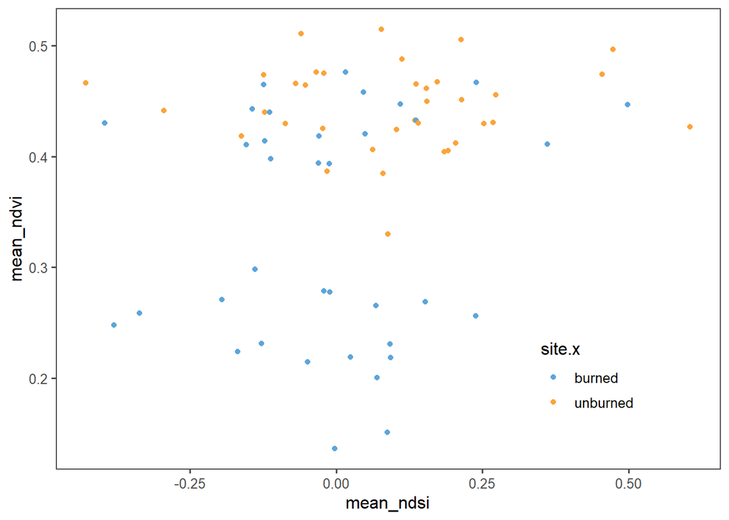

```r
sum_2 <- inner_join(x = sum_aug, y = sum_jan, by = "year-site")

#Figure 2
ggplot(sum_2,aes(x=mean_ndsi,y=mean_ndvi,color=site.x)) +
  geom_point() +
  theme_few() +
  scale_color_few() +
  theme(legend.position=c(0.8,0.2))
```

Figure 2. Above we can observe a poor correlation between the two indices NDSI and NDVI, especially in the burned sites. This makes logical sense because snowfall will accumulate where it falls, somewhat according to topography, and by the time productive growing season approaches, all that snow pack will be gone. The soil can only hold a certain amount of water and anything beyond that will just run off or drain out. There does seem to be some grouping of burned NDSI and NDVI values, this indicates the impact of the fire on reducing NDVI values along the same NDSI range.

## Q3

How is the snow effect from question 2 different between pre- and post-burn and burned and unburned?

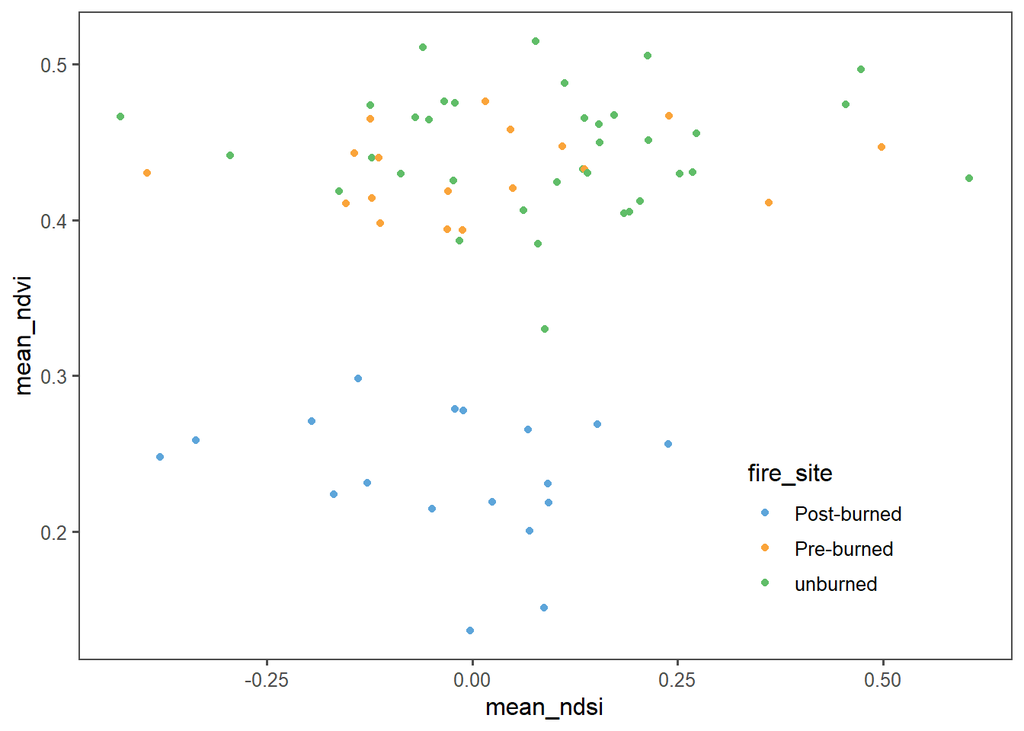

```r
sum_3 <- sum_2 %>%
  mutate(fire = ifelse(year.x >= 2002, "Post", "Pre")) %>%
  mutate(fire_site = ifelse(site.x == "burned", paste(fire,site.x,sep="-"), site.x)) %>%
  select(-c("year-site","year.y","site.y","fire"))


#Figure 3
ggplot(sum_3,aes(x=mean_ndsi,y=mean_ndvi,color=fire_site)) +
  geom_point() +
  theme_few() +
  scale_color_few() +
  theme(legend.position=c(0.8,0.2))
```

Figure 3.

There is not much of a trend observed in both burned and unburned plots, though there is a slightly tighter trend between NDSI and NDVI in the unburned areas if we discount the year. The only difference that was observed is that the burned plots have a wider variance in yearly NDVI across the same NDSI when compared to plots that were unburned. THis passes the logic test, more moisture will have more of an impact on areas that can actually utilize the water.

## Question 4

What month is the *greenest* month on average?

```r
sum_full <- full_wide %>%
  group_by(month) %>%
  summarise(ndvi_mon =mean(ndvi),
            ndsi_mon =mean(ndsi))
greenest <- slice_max(sum_full, ndvi_mon)
greenest
```

```
## # A tibble: 1 x 3
##   month ndvi_mon ndsi_mon
##   <dbl>    <dbl>    <dbl>
## 1     8    0.387   -0.459
```

What month is the snowiest on average?

```r
snowiest <- slice_max(sum_full,ndsi_mon)
snowiest
```

```
## # A tibble: 1 x 3
##   month ndvi_mon ndsi_mon
##   <dbl>    <dbl>    <dbl>
## 1     1    0.219    0.210
```

On average, January is the *snowiest* month.